# 624 Project1

### Diagnostic analysis-Residual Plots:

Residual plots

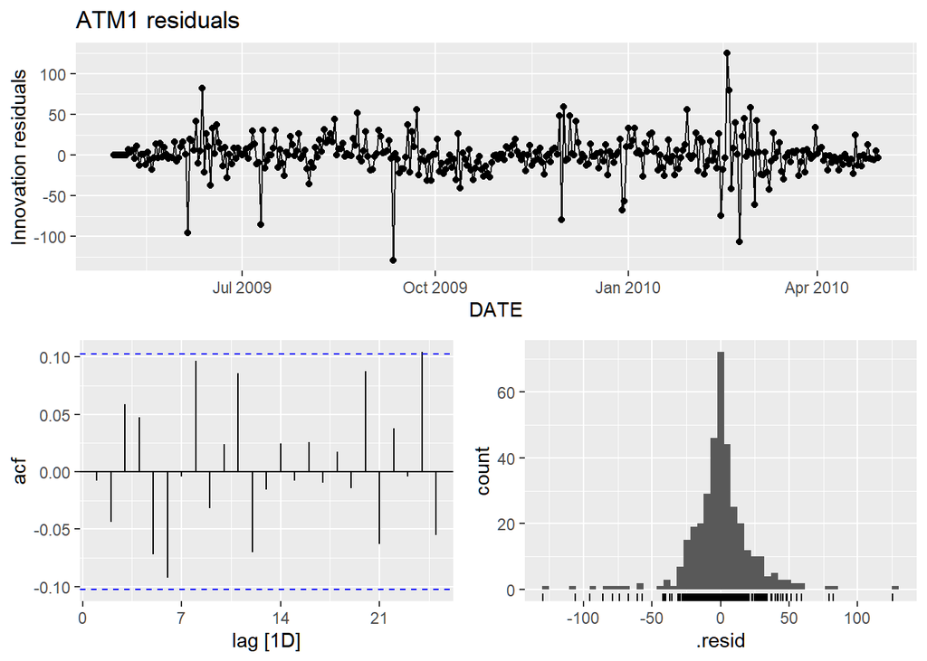

```r
#checking for residual plots and ljung_box test for white-noise:
#ATM1
atm_fit124 %>%
  filter(ATM=='ATM1') %>%
  select(auto_arima) %>%
  gg_tsresiduals() + ggtitle('ATM1 residuals')
```

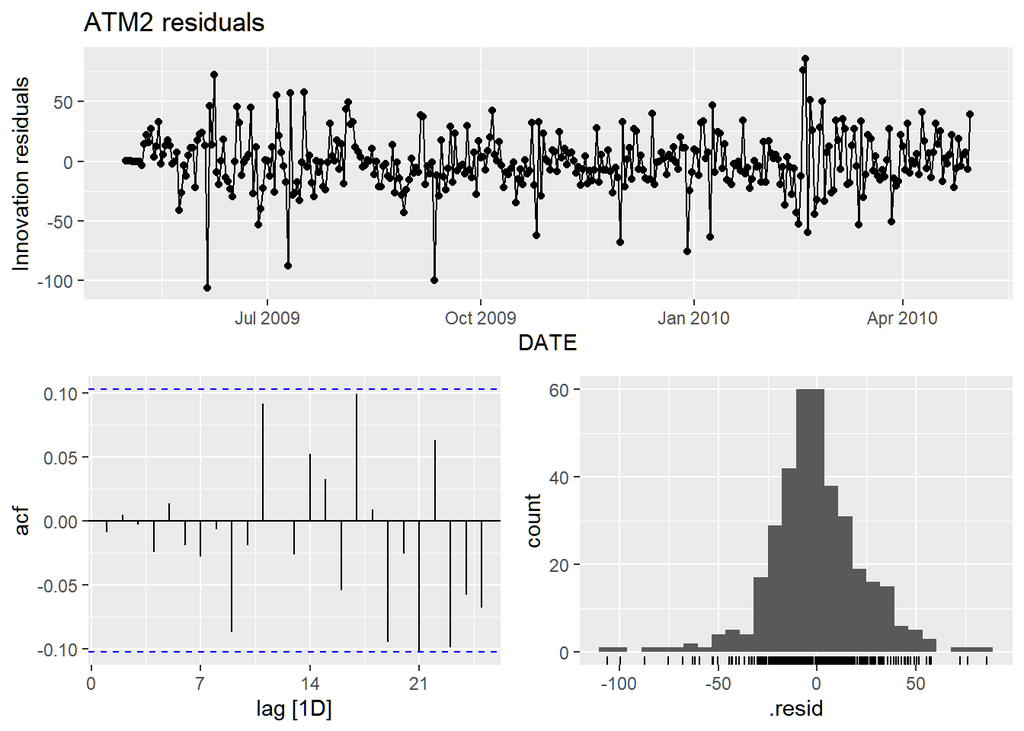

```r
#ATM2
atm_fit124 %>%
  filter(ATM=='ATM2') %>%
  select(auto_arima) %>%
  gg_tsresiduals() + ggtitle('ATM2 residuals')
```

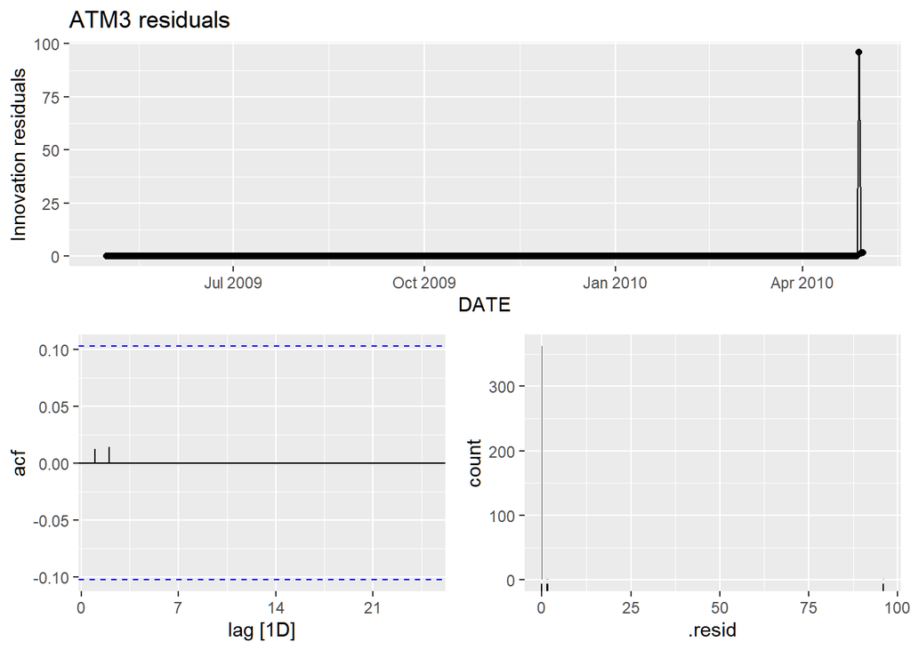

```r
#ATM3
atm_fit3 %>%
  select(auto_arima) %>%
  gg_tsresiduals() + ggtitle('ATM3 residuals')
```

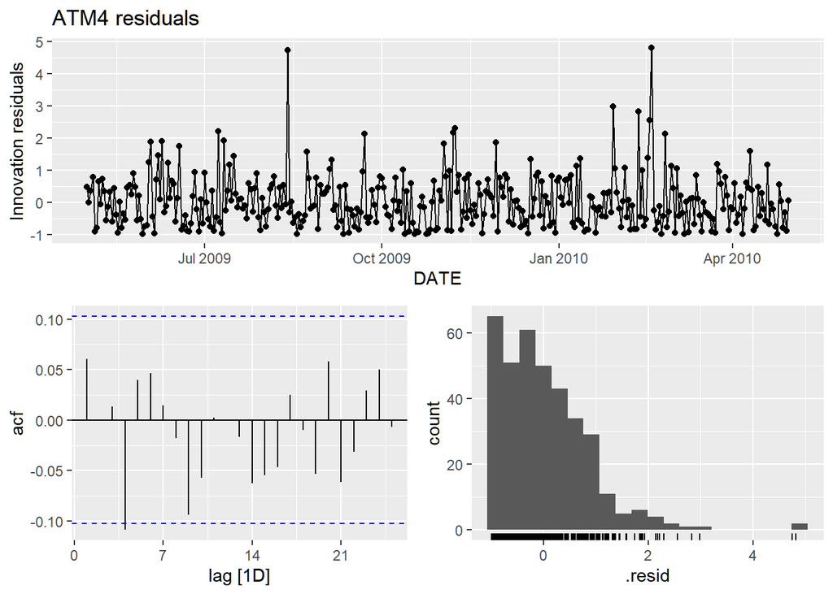

```r
#ATM4
atm_fit124 %>%
  filter(ATM=='ATM4') %>%
  select(`ETS(Cash)`) %>%
  gg_tsresiduals() + ggtitle('ATM4 residuals')
```

### Diagnostic analysis- Ljung-Box Test:

All the models passed with p-value >0.05

```r
#ATM1 model:
atm_fit124 %>%
  filter(ATM=='ATM1') %>%
  select(auto_arima) %>%
  augment() %>%
  features(.innov, ljung_box, lag = 10, dof = 3)
```

```
## # A tibble: 1 × 3
##   .model     lb_stat lb_pvalue
##   <chr>        <dbl>     <dbl>
## 1 auto_arima    12.0     0.100
```

```r
#ATM2 model:
atm_fit124 %>%
  filter(ATM=='ATM2') %>%
  select(auto_arima) %>%
  augment() %>%
  features(.innov, ljung_box, lag = 10, dof = 6)
```

```
## # A tibble: 1 × 3
##   .model     lb_stat lb_pvalue
##   <chr>        <dbl>     <dbl>
## 1 auto_arima    3.78     0.437
```

```r
#ATM3 model:
atm_fit3 %>%
  select(auto_arima) %>%
  augment() %>%
  features(.innov, ljung_box, lag = 10, dof = 2)
```

```
## # A tibble: 1 × 3
##   .model     lb_stat lb_pvalue
##   <chr>        <dbl>     <dbl>
## 1 auto_arima   0.132      1.00
```

```r
#ATM4 model:
atm_fit124 %>%
  filter(ATM=='ATM4') %>%
  select(`ETS(Cash)`) %>%
  augment() %>%
  features(.innov, ljung_box, lag = 10)
```

```
## # A tibble: 1 × 3
##   .model    lb_stat lb_pvalue
##   <chr>       <dbl>     <dbl>
## 1 ETS(Cash)    12.0     0.288
```

### Result output to an excel sheet:

```r
#exporting ATM 1 - 3 and ATM 4 will be in a
atm_output123<- atm_fc %>%
  filter(.model == 'auto_arima', ATM!='ATM4')
atm_output4<- atm_fc %>%
  filter(.model == 'ETS(Cash)', ATM=='ATM4')

#combining the fables and convert them into dataframe for exporting:
atm_output_combo <- bind_rows(atm_output123, atm_output4) %>%
  as.data.frame() %>%
  select(ATM, DATE, .mean) %>%
  rename(Cash = .mean)
#To export:
write_xlsx(atm_output_combo, 'partA_atm_output_combo.xlsx')
```

## Monthly forecast of power usage in 2014: Loading data:

```r
url2<- 'https://raw.githubusercontent.com/stormwhale/data-mines/refs/heads/main/ResidentialCustomerForecastLoad-624.csv'
power<- read.csv(url2)

#checking column types:
str(power)
```

```
## 'data.frame':    192 obs. of  3 variables:
##  $ CaseSequence: int  733 734 735 736 737 738 739 740 741 742 ...
##  $ YYYY.MMM    : chr  "1998-Jan" "1998-Feb" "1998-Mar" "1998-Apr" ...
##  $ KWH         : int  6862583 5838198 5420658 5010364 4665377 6467147 8914755 8607428 6989888 6345620 ...
```

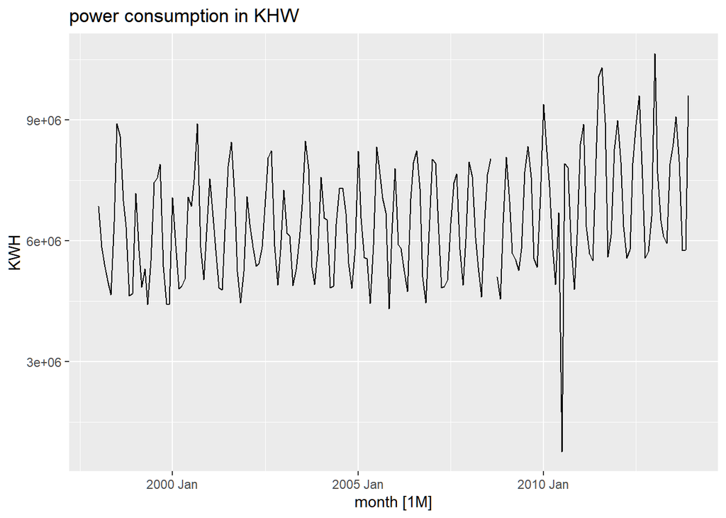

```r
#convert dataframe to tsibble:
power<- power %>%
  mutate(month = yearmonth(YYYY.MMM)) %>%
  select(-YYYY.MMM) %>%
  as_tsibble(index = month) %>%
  arrange(month, desc=TRUE)

#To visualize
power %>% autoplot(KWH)+ggtitle('power consumption in KHW')
```

### To check for missing values:

```r
power %>%
  filter(is.na(KWH)) # 1 missing value from CaseSequence 861
```

```
## # A tsibble: 1 x 3 [1M]
##   CaseSequence   KWH    month
##          <int> <int>    <mth>
## 1          861    NA 2008 Sep
```

```r
#We will impute the missing value with the mean KWH from the dataset:
power<- power %>%
  mutate(KWH = if_else(is.na(KWH), mean(KWH, na.rm=TRUE), KWH))

#Double check the imputed value:
power %>%
  filter(CaseSequence==861)
```

```
## # A tsibble: 1 x 3 [1M]
##   CaseSequence      KWH    month
##          <int>    <dbl>    <mth>
## 1          861 6502475. 2008 Sep
```

```r
#checking for missing values:
any(is.na(power)) #False
```

```
## [1] FALSE
```

### Possible transformations on the dataset:

The transformation might not help with the outlier as it amplified the outlier’s effect.

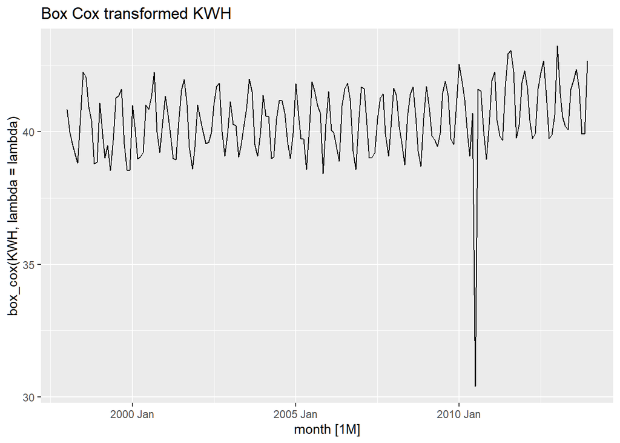

```r
#Trying out box_cox transformation to stabilize the variance:
lambda<- power %>%
  features(KWH, box_cox, feature=guerrero) %>%
  pull(lambda_guerrero)

#plotting the transformed data:
power %>%
  autoplot(box_cox(KWH, lambda = lambda)) +
  ggtitle('Box Cox transformed KWH')
```

### To fit the data without the transformation:

```r
#Fitting different models:
power_fit<- power %>%
  model(
    ETS = ETS(KWH),
    auto_arima = ARIMA(KWH, stepwise = FALSE),
    snaive = SNAIVE(KWH)
  )
```

### To check the models selected automatically:

```r
power_fit_long<- power_fit %>%
  pivot_longer(everything(),
               values_to= 'order',
               names_to = 'model')
print(power_fit_long)
```

```
## # A mable: 3 x 2
## # Key:     model [3]
##   model                                   order
##   <chr>                                 <model>
## 1 ETS                              <ETS(M,N,M)>
## 2 auto_arima <ARIMA(0,0,1)(1,1,1)[12] w/ drift>
## 3 snaive                               <SNAIVE>
```

### To compare the performance of each model against each other:

auto_arima out performs the snaive benchmark and the ETS(M,N,M) model

```r
accuracy(power_fit)
```

```
## # A tibble: 3 × 10
##   .model     .type         ME     RMSE     MAE   MPE  MAPE  MASE RMSSE   ACF1
##   <chr>      <chr>      <dbl>    <dbl>   <dbl> <dbl> <dbl> <dbl> <dbl>  <dbl>
## 1 ETS        Training  60461.  834738. 505667. -4.37  12.1 0.725 0.708 0.174
## 2 auto_arima Training -25069.  827744. 493541. -5.51  11.7 0.708 0.702 0.0128
## 3 snaive     Training  94245. 1178792. 697453. -3.94  14.6 1     1     0.231
```

### The auto_arima model is selected for the forecast:

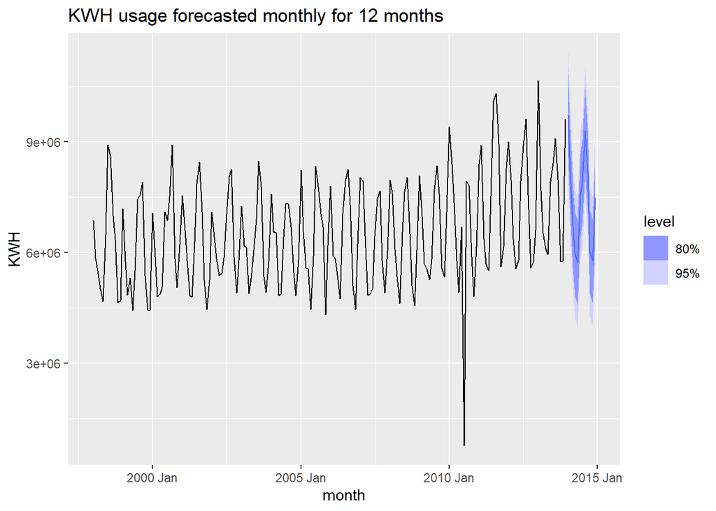

```r
power_fc<- power_fit  %>%
  select('auto_arima') %>%
  forecast(h = '12 month')

#To visualize:
power_fc %>% autoplot(power) +
  ggtitle('KWH usage forecasted monthly for 12 months')
```

### Diagnostic analysis:

Ljung-box P-Value = 0.52, indicating that the residuals are white-noise and the model is fairly well fitted

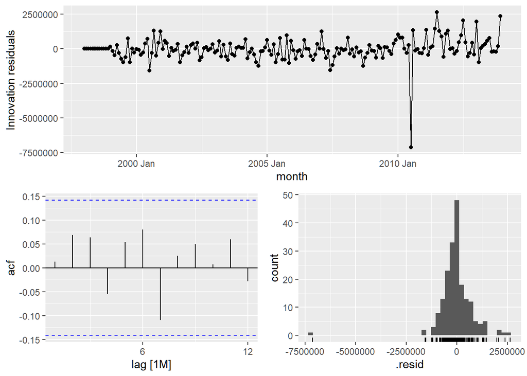

```r
#Except for one outlier, the residuals are all well within acceptable range for variation
power_fit %>%
  select(auto_arima) %>%
  gg_tsresiduals(lag = 12)
```

```r
#ljung-box test:
power_fit %>%
  select(auto_arima) %>%
  augment() %>%
  features(.innov, ljung_box, lag = 12, dof = 3)
```

```
## # A tibble: 1 × 3
##   .model     lb_stat lb_pvalue
##   <chr>        <dbl>     <dbl>
## 1 auto_arima    8.17     0.517
```

### Exporting the results:

```r
expo<- power_fc %>%
  as.data.frame() %>%
  select(month, .mean) %>%
  rename(KWH = .mean) %>%
  mutate(month = as.character(month))

write_xlsx(expo, "Part_B_KWH.xlsx")
```

### Part B Conclusion:

Box-cox transformation was first considered to stabilize the dataset’s variations. However, after visualizing the transformed data, the outlier’s effect was seen amplified and the raw without the transformation performed fairly well in the fitted model. Thus, transformation of the data was not considered as it may negatively impact the modeling of the dataset and decrease the interpretability. An ARIMA(0,0,1)(1,1,1) was autoselected with step-wise function turned off to increase the search parameters of the model. This ARIMA model out-performs the ETS and the benchmark SNAIVE model and was selected to forecast the data. The residual plots and the Ljung-box test (P-value > 0.05) showed that the residuals are considered to be white-noises and there is not patterns or auto-correlations between them. This model is well fitted to forecast this dataset.

## Bonus part C:

### loading the data:

```r
url1<- 'https://raw.githubusercontent.com/stormwhale/data-mines/refs/heads/main/Waterflow_Pipe1.csv'
url2<- 'https://raw.githubusercontent.com/stormwhale/data-mines/refs/heads/main/Waterflow_Pipe2.csv'

water1<- read.csv(url1)
water2<- read.csv(url2)
```

### Convert the data into date format:

```r
#Convert the Date.Time column into date format.
water1<- water1 %>%
  rename(Date = 'Date.Time') %>%
  mutate(Date = as.POSIXct(Date, format='%m/%d/%y %I:%M %p'))

water2<-water2 %>%
  rename(Date = 'Date.Time') %>%
  mutate(Date = as.POSIXct(Date, format='%m/%d/%y %I:%M %p'))
```

### To combine the two data into one:

```r
#To combine the two data into one:
water_combo<- rbind(water1, water2)

#Checking for missing values:
any(is.na(water_combo)) #None
```

```
## [1] FALSE
```

### Taking the mean values for the Dates that are within an hour:

First we will round the time to the nearest hour from the Date column, then extract and group the hours together and get the average value. Finally, we will only consider one time period for the same day with different hours.

```r
avg_waterflow<- water_combo %>%
  mutate(hour = floor_date(Date, unit = 'hour')) %>% #To round and extract the hour
  group_by(hour) %>%
  mutate(avg_waterflow = mean(WaterFlow)) %>%
  ungroup() %>%
  distinct(hour, avg_waterflow) #Extract only the unique value

#To convert this new averaged data into tsibble:
ts_water<-avg_waterflow %>%
  as_tsibble(index=hour)

head(ts_water)
```

```
## # A tsibble: 6 x 2 [1h] <?>
##   hour                avg_waterflow
##   <dttm>                      <dbl>
## 1 2015-10-23 00:00:00          26.1
## 2 2015-10-23 01:00:00          18.8
## 3 2015-10-23 02:00:00          24.5
## 4 2015-10-23 03:00:00          25.6
## 5 2015-10-23 04:00:00          22.4
## 6 2015-10-23 05:00:00          23.6
```

### To visualize the data:

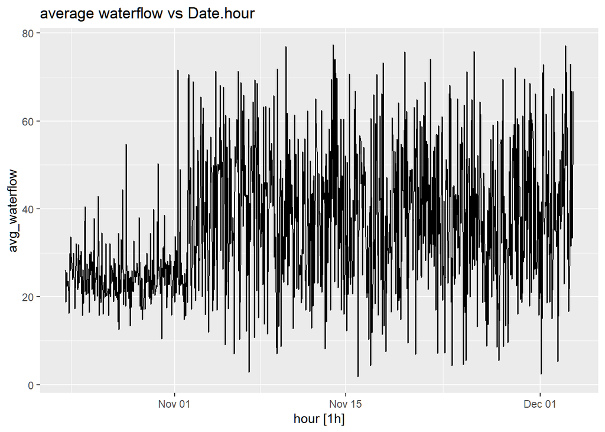

```r
ts_water %>%
  autoplot(avg_waterflow) +
  ggtitle('average waterflow vs Date.hour')
```

### To check if the combined dataset is stationary and if not, how many differencing is needed to make it stationary:

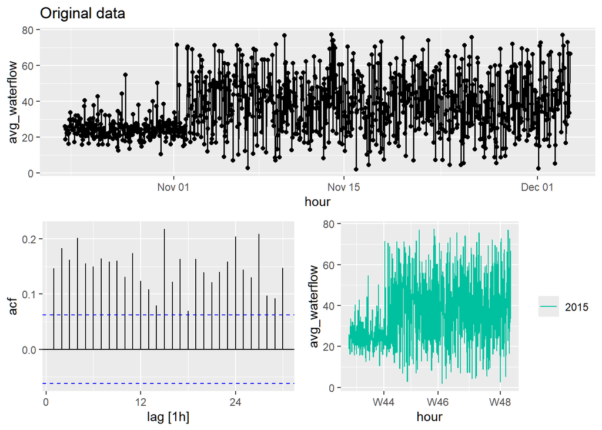

```r
#The data is not stationary and will need differencing to stabilize it.
ts_water %>%
  gg_tsdisplay(avg_waterflow)+ggtitle('Original data')
```

```r
#To check how many degrees of differencing is needed:
ts_water %>%
  features(avg_waterflow, unitroot_ndiffs) #needs 1 differencing
```

```
## # A tibble: 1 × 1
##   ndiffs
##    <int>
## 1      1
```

```r
#To check if seasonal differencing is needed:
ts_water %>%
  features(avg_waterflow, unitroot_nsdiffs) #No seasonal differencing is needed
```

```
## # A tibble: 1 × 1
##   nsdiffs
##     <int>
## 1       0
```

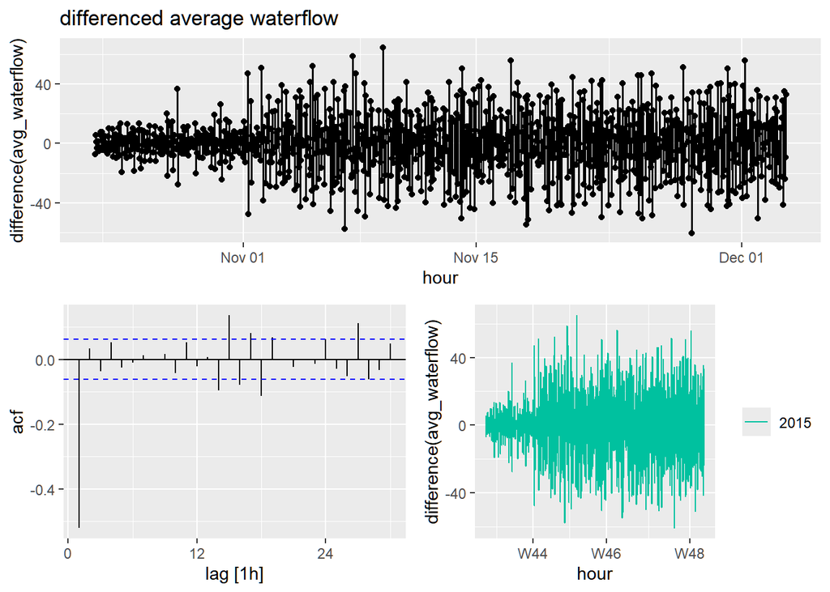

```r
#Re-check if the differenced data is stationary:
ts_water %>%
  gg_tsdisplay(difference(avg_waterflow))+
  ggtitle('differenced average waterflow')
```

```r
#Then check with kpss test:
ts_water %>%
  features(difference(avg_waterflow), unitroot_kpss)
```

```
## # A tibble: 1 × 2
##   kpss_stat kpss_pvalue
##       <dbl>       <dbl>
## 1   0.00750         0.1
```

```r
#P-value = 0.1. The data appears to be stationary
```

### Check to see if data needs transformation, using Box-Cox lambda value:

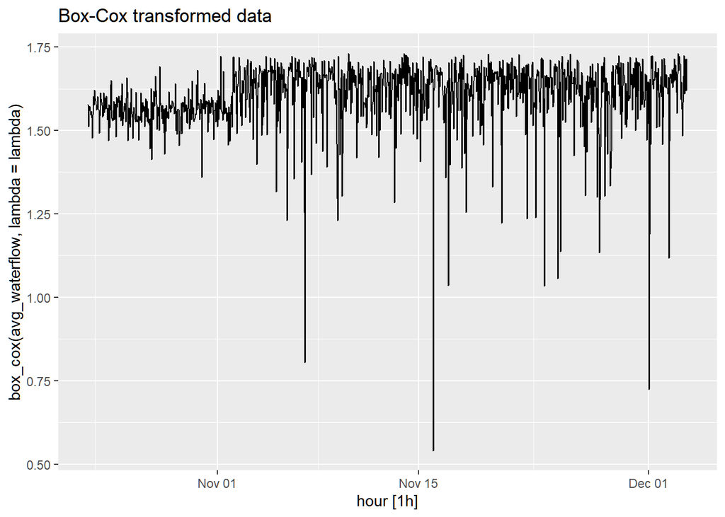

```r
lambda<- ts_water %>%
  features(avg_waterflow, box_cox, feature = guerrero) %>%
  pull(lambda_guerrero )

#visualize the transformed data:
ts_water %>%
  autoplot(box_cox(avg_waterflow, lambda= lambda)) + ggtitle('Box-Cox transformed data')
```

The box-cox transformation does not seem to improve the variance by much and also amplifies some of the spikes. We will keep it aside and fit models without it for now.

### Fitting the waterflow data into model without the transformation:

```r
water_fit<- ts_water %>%
  model(
    auto_ETS = ETS(avg_waterflow),
    ETS_MNA = ETS(avg_waterflow ~ error('M') + trend('N') + season('A')),
    ETS_MNM = ETS(avg_waterflow ~ error('M') + trend('N') + season('M')),
    auto_arima = ARIMA(avg_waterflow, stepwise = FALSE),
    snaive = SNAIVE(avg_waterflow)
  )
```

The Snaive model is added as a benchmark for the model testing. Two manually selected ETS model (M,N,A) and ETS (M,N,M) are included to capture the seasonality pattern in the data. An auto_selected ARIMA model is also included.

### To check the RMSE for each model and select the lowest one for best fit:

```r
accuracy(water_fit) %>% select(.model, RMSE, MAE, RMSSE)
```

```
## # A tibble: 5 × 4
##   .model      RMSE   MAE RMSSE
##   <chr>      <dbl> <dbl> <dbl>
## 1 auto_ETS    14.6  11.2 0.742
## 2 ETS_MNA     14.4  11.1 0.734
## 3 ETS_MNM     14.4  11.1 0.734
## 4 auto_arima  14.5  11.1 0.739
## 5 snaive      19.7  15.1 1
```

### Check the models selected for the auto ETS and ARIMA:

```r
water_fit_long<- water_fit %>%
  pivot_longer(everything(),
               values_to = 'order',
               names_to = 'model')

print(water_fit_long)
```

```
## # A mable: 5 x 2
## # Key:     model [5]
##   model                          order
##   <chr>                        <model>
## 1 auto_ETS                <ETS(M,N,N)>
## 2 ETS_MNA                 <ETS(M,N,A)>
## 3 ETS_MNM                 <ETS(M,N,M)>
## 4 auto_arima <ARIMA(0,1,1)(0,0,1)[24]>
## 5 snaive                      <SNAIVE>
```

### Visualizing the forecasted data with the ETS_MNM model:

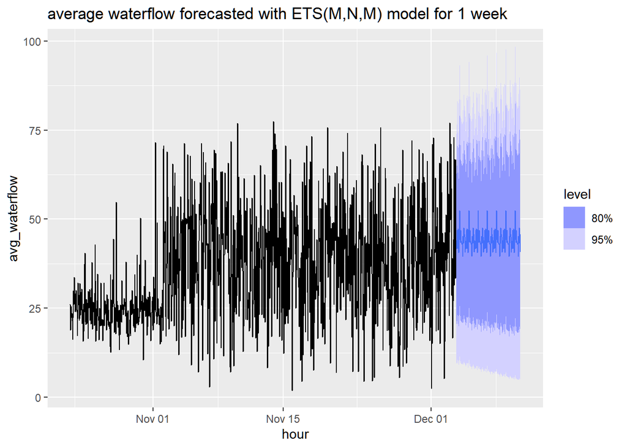

```r
water_fc<- water_fit %>%
  select(ETS_MNM) %>%
  forecast(h= '1 week')

water_fc %>%
  autoplot(ts_water) +
  ggtitle('average waterflow forecasted with ETS(M,N,M) model for 1 week')
```